# Online media coverage before and after the Bundestag elections in 2017

Franziska Löw

06 Sep 2020

# 1. Introduction

In this paper I develop and apply a machine learning approach based on structural topic modeling in combination with cosine similarity and a regression discontinuity framework in order to identify similarities between topics addressed in press releases and online news articles of different media sources before and after the Bundestag elections that took place the 24th of Sep 2017.

**Research question**:

How does media coverage change after the election day for different parties?

**Method**:

1. Estimate a **structural topic model** to obtain a topic distribution for each document (press release or news article)
2. Estimate the **cosine similarity** of topic distribution between documents of the same week (Hier könnte man überlegen ob es mehr Sinn macht eher die Dokumente +/-7 Tage zu nehmen)

Cosine similarity is built on the geometric definition of the dot product of two vectors. It is a measure for the distance between two vectors and is defined between zero and one; values towards 1 indicate similarity.

$$\text{cosine similarity} = \text{cos}(\theta)=\frac{a*b}{||a|| ||b||}$$
As topic proportions per news article / press release are vectors of the same length, the cosine similarity allows a comparison of the topic distribution between two documents.

Applications of cosine similarity to compare of topic model outcomes: [Ramage et al. 2010](https://citeseerx.ist.psu.edu/viewdoc/download?doi=10.1.1.224.8995&rep=rep1&type=pdf), [Rehs 2020](https://link.springer.com/article/10.1007/s11192-020-03640-0#Sec8)

3. Estimate a **regression discontinuity model** for each media outlet $i$

$$\text{CosineSimilarity}_{i}=\beta_0+\beta_1T_i+\beta_nDn_{j}+\beta_{n+n}T_iDn_{j}+\epsilon_i$$
where the $D2_{j}, D3_{j}, ... ,Dn_{j}$ represent dummy variables for a political party $j$

$$T_i = 1 \text{ if date } >= \text{election date} \\
T_i = 0 \text{ if date } < \text{election date}$$
so that the receipt of treatment $T_i$ is determined by the threshold $c$ (election day) of the continuous variable $W_i$ (date), the so called running variable. The idea of regression regression discontinuity design is to use observations with a $W_i$ close to $c$ for the estimation of $\beta_1$. $\beta_1$ is the average treatment effect for observations with $W_i = c$ which is assumed to be a good approximation to the overall treatment effect. In other words, $\beta_1$ gives us the average change of news coverage of media outlet $i$ after the election day. Since interaction terms $T_iDn_{j}$ are included, we can estimate the treatment effect for each party.

# 2. Structural topic model

Parties want the media agenda to be congruent with their own agenda to define the issue-based criteria on which they will be evaluated by voters ( [Eberl, 2017](https://journals.sagepub.com/doi/abs/10.1177/0093650215614364) ). Thus, parties instrumentalize their press releases in order to highlight issues that they are perceived to be competent on, that they “own” and that are important to their voters ( [Kepplinger & Maurer, 2004](https://link.springer.com/chapter/10.1007%2F978-3-322-83381-5_9) ). Editors can select from this universe and decide which of these topics will be discussed in the news. In that sense the ideological content of a newspaper refers to the extent to which the topics promoted by the parties correlate with the topics discussed in the news articles.

To discover the latent topics in the corpus of press releases and news articles, a structural topic modeling (STM) developed by [Roberts (2016)](https://scholar.princeton.edu/sites/default/files/bstewart/files/a_model_of_text_for_experimentation_in_the_social_sciences.pdf) is applied. The STM is an unsupervised machine learning approach that models topics as multinomial distributions of words and documents as multinomial distributions of topics, allowing to incorporate external variables that effect both, topical content and topical prevalence.

## 2.1 Results of the STM

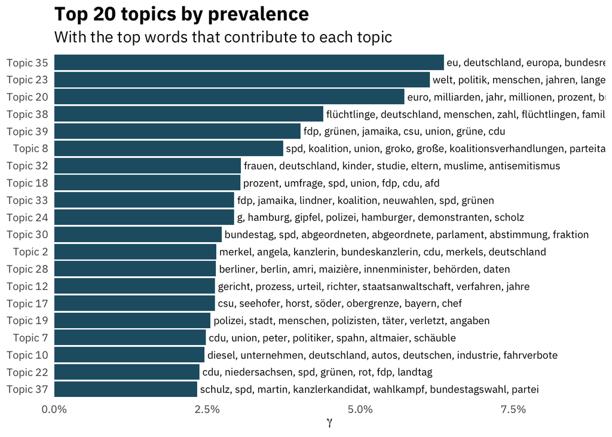

To explore the words associated with each topic we use the words with the highest probability in each topic. As we included the source type (press release or news paper) as a control for the topical content (the word distribution of each topic), we have two different labels for each topic.

# 3. Cosine similarity

Cosine similarity is built on the geometric definition of the dot product of two vectors.

$$\text{cosine similarity} = \text{cos}(\theta)=\frac{a*b}{||a|| ||b||}$$

```r
cosine_sim <- function(a, b) crossprod(a, b) / sqrt(crossprod(a) * crossprod(b))
```

```r
calc_cos_sim <- function(doc_code,
                         gamma_mat = gamma) {
  # find the doc
  doc_col_index <- which(colnames(gamma_mat) == as.character(doc_code))
  # get the week of the doc
  year_week_target <- filter(model_df, doc_index == doc_code)$year_week
  # get all doc_codes that are in the same week
  doc_code_pairs <- filter(model_df, year_week == year_week_target)$doc_index
  # calculate cosine similarity for each document based on gamma
  # apply(..., 2) iterates over the columns of a matrix
  cos_sims <- apply(gamma_mat[, doc_code_pairs], 2,
    FUN = function(y) cosine_sim(gamma_mat[, doc_col_index], y)
  )

  # return results as data frame
  data_frame(
    year_week = year_week_target,
    doc_code1 = doc_code,
    doc_code2 = as.numeric(names(cos_sims)),
    cos_sim = cos_sims
  ) %>%
    filter(doc_code2 != doc_code) # remove self reference
}
```

Calculate the cosine similarity for our sample document and all other documents and display the top 5 documents (the 5 documents most similar).

```r
calc_cos_sim(sample_doc) %>%
  mutate(doc_index = doc_code2) %>%
  left_join(.,
    model_df %>%
      select(title, source, doc_index, type),
    by = "doc_index"
  ) %>%
  filter(type == "press") %>%
  arrange(desc(cos_sim)) %>%
  top_n(5, cos_sim) %>%
  select(title, source, cos_sim)
```

| title | source | cos_sim |
| --- | --- | --- |
| Weidel/Protschka: Glyphosat-Verlängerung ist ein Skandal | AfD | 0.8039572 |
| André Poggenburg: Glyphosat – Keine Zulassung ohne Klärung der wirklichen Schädlichkeit | AfD | 0.7821429 |
| Verantwortung für Tierwohl endet nicht an der Grenze | SPD | 0.6481036 |
| Dokumente aus dem EU-Vermittlungsausschuss zeigen: Glyphosat-Beschluss ist ein einziges Trauerspiel | DIE LINKE | 0.5568073 |
| Fakten müssen für Zulassung von Pflanzenschutzmitteln maßgeblich sein | FDP | 0.4740893 |

Finally, the function will be applied to all documents.

```r
run_cos_sim_loop <- function(target) {
  small_df <- model_df %>% filter(source == target)
  doc_indices <- small_df$doc_index

  print(paste("Number of documents:", length(doc_indices)))

  rm(cosine_distances)
  i <- 1
  for (x in doc_indices) {
    print(i)
    temp <- calc_cos_sim(x, gamma)

    # append the results to a data frame
    cosine_distances <- if (!exists("cosine_distances")) temp else rbind(cosine_distances, temp)

    i <- i + 1
  }

  cosine_distances
}
```

# 4. Estimate Model

```r
library(broom)
library(magrittr)
library(tidyverse)
rm(list = ls())

load("../output/model40_weekly_source.Rda")
election_date <- as.Date("24Sep2017", "%d%b%Y")

model_df <- model_df %>%
  dplyr::mutate(
    doc_index = as.numeric(rownames(.)),
    election_dummy = as.factor(ifelse(date <= election_date, "pre", "post")),
    year_week = lubridate::floor_date(date, "1 week")
  )
```

```r
df_prep <- function(cosine_df) {
  cosine_df %>%
    left_join(., model_df %>%
      transmute(
        doc_code1 = doc_index,
        source1 = source, type1 = type,
        date1 = date
      ),
    by = "doc_code1"
    ) %>%
    left_join(., model_df %>%
      transmute(
        doc_code2 = doc_index,
        source2 = source, type2 = type,
        date2 = date
      ),
    by = "doc_code2"
    ) %>%
    group_by(date1, source2, type2) %>%
    summarise(cos_sim = mean(cos_sim, na.rm = TRUE)) %>%
    ungroup() %>%
    mutate(election_dummy = as.factor(ifelse(date1 <= election_date, "pre", "post")))
}
```

## 4.2. OLS dummy

```r
calc_dumm <- function(dataframe, target_source) {
  temp_df <- dataframe %>%
    filter(type2 == "press")

  model_outcome <- temp_df %$%
    lm(log(cos_sim) ~ source2)
}
```

```r
# ----------------------------
target_source <- "DIE WELT"
load(paste0("../output/cosine_dist_", target_source, ".Rda"))
cosine_distances_df <- df_prep(welt)
welt_model <- calc_dumm(cosine_distances_df, target_source)

target_source <- "stern.de"
load(paste0("../output/cosine_dist_", target_source, ".Rda"))
cosine_distances_df <- df_prep(stern)
stern_model <- calc_dumm(cosine_distances_df, target_source)

target_source <- "ZEIT ONLINE"
load(paste0("../output/cosine_dist_", target_source, ".Rda"))
cosine_distances_df <- df_prep(zeit)
zeit_model <- calc_dumm(cosine_distances_df, target_source)

target_source <- "Handelsblatt"
load(paste0("../output/cosine_dist_", target_source, ".Rda"))
cosine_distances_df <- df_prep(handelsblatt)
handelsblatt_model <- calc_dumm(cosine_distances_df, target_source)

target_source <- "FOCUS Online"
load(paste0("../output/cosine_dist_", target_source, ".Rda"))
cosine_distances_df <- df_prep(focus)
focus_model <- calc_dumm(cosine_distances_df, target_source)

target_source <- "Bild.de"
load(paste0("../output/cosine_dist_", target_source, ".Rda"))
cosine_distances_df <- df_prep(bild)
bild_model <- calc_dumm(cosine_distances_df, target_source)

target_source <- "SPIEGEL ONLINE"
load(paste0("../output/cosine_dist_", target_source, ".Rda"))
cosine_distances_df <- df_prep(spiegel)
spiegel_model <- calc_dumm(cosine_distances_df, target_source)
```

```r
stargazer::stargazer(welt_model, stern_model, zeit_model, handelsblatt_model, focus_model, bild_model, spiegel_model,
                     column.labels = c("DIE WELT", "stern.de", "ZEIT ONLINE", "Handelsblatt", "FOCUS Online", "Bild.de", "SPIEGEL ONLINE"),
                     dep.var.labels = paste0("Cosine similarity of topic distribution"),
                     single.row = TRUE,
                     #font.size = "tiny",
                     type = "text")
```

```
##
## ============================================================================================================================================================================================
##                                                                                               Dependent variable:
##                     ------------------------------------------------------------------------------------------------------------------------------------------------------------------------
##                                                                                     Cosine similarity of topic distribution
##                             DIE WELT                stern.de               ZEIT ONLINE           Handelsblatt           FOCUS Online               Bild.de               SPIEGEL ONLINE
##                               (1)                      (2)                     (3)                   (4)                    (5)                      (6)                      (7)
## --------------------------------------------------------------------------------------------------------------------------------------------------------------------------------------------
## source2B90/GRÜNE       -0.249*** (0.036)        -0.235*** (0.045)       -0.213*** (0.055)       0.049 (0.048)        -0.333*** (0.038)        -0.326*** (0.054)        -0.229*** (0.044)
## source2CDU             -0.290*** (0.033)        -0.203*** (0.042)       -0.262*** (0.051)       0.014 (0.045)        -0.313*** (0.036)        -0.311*** (0.051)        -0.248*** (0.041)
## source2DIE LINKE       -0.298*** (0.033)        -0.150*** (0.042)       -0.222*** (0.051)       0.059 (0.045)        -0.315*** (0.036)        -0.311*** (0.051)        -0.225*** (0.041)
## source2FDP             -0.267*** (0.033)        -0.177*** (0.042)       -0.197*** (0.051)       0.050 (0.045)        -0.321*** (0.036)        -0.323*** (0.051)        -0.227*** (0.041)
## source2SPD             -0.304*** (0.034)        -0.193*** (0.043)       -0.259*** (0.052)       0.011 (0.045)        -0.350*** (0.036)        -0.357*** (0.051)        -0.296*** (0.042)
## Constant               -1.746*** (0.024)        -1.972*** (0.030)       -1.749*** (0.036)     -1.835*** (0.031)      -1.812*** (0.025)        -1.730*** (0.036)        -1.861*** (0.029)
## --------------------------------------------------------------------------------------------------------------------------------------------------------------------------------------------
## Observations                 1,376                    1,382                   1,408                 1,204                  1,432                    1,326                    1,428
## R2                           0.082                    0.027                   0.025                 0.003                  0.088                    0.050                    0.042
## Adjusted R2                  0.078                    0.023                   0.021                 -0.002                 0.085                    0.046                    0.038
## Residual Std. Error    0.366 (df = 1370)        0.463 (df = 1376)       0.570 (df = 1402)     0.457 (df = 1198)      0.401 (df = 1426)        0.547 (df = 1320)        0.461 (df = 1422)
## F Statistic         24.339*** (df = 5; 1370) 7.507*** (df = 5; 1376) 7.137*** (df = 5; 1402) 0.617 (df = 5; 1198) 27.594*** (df = 5; 1426) 13.769*** (df = 5; 1320) 12.406*** (df = 5; 1422)
## ============================================================================================================================================================================================
## Note:                                                                                                                                                            *p<0.1; **p<0.05; ***p<0.01
```

## 4.2. Regression discontinuity model

Calculate a regression discontinuity model for each newspaper $i$.

$$\text{CosineSimilarity}_{i}=\beta_0+\beta_1T_i+\beta_2W_{centered}+\beta_nDn_{j}+\beta_{n+n}T_iDn_{j}+\epsilon_i$$

where $D2_{j}, D3_{j}, ... ,Dn_{j}$ represent dummy variables for a political party $j$ and $W_{centered} = $ date - election day.

$$T_i = 1 \text{ if date } >= \text{election date} \\
T_i = 0 \text{ if date } < \text{election date}$$

```r
plot_data <- function(dataframe) {
  cosine_distances_df %>%
    filter(type2 == "press") %>%
    ggplot(aes(date1, cos_sim, color = election_dummy)) +
    geom_point(show.legend = F) +
    geom_vline(xintercept = election_date) +
    ggthemes::theme_clean() +
    labs(y = "Cosine similarity of topic distribution", x = "") +
    facet_wrap(~source2)
}
```

```r
calc_rd_dummy<- function(dataframe, target_source) {
  temp_df <- dataframe %>%
    filter(type2 == "press") %>%
    mutate(
      X_centered = I(date1 - election_date),
      treatedTRUE = ifelse(date1 >= election_date, 1, 0))

  model_outcome <- temp_df %$%
    lm(log(cos_sim) ~ treatedTRUE + source2 + X_centered)
}

calc_rd_dummy_interaction <- function(dataframe, target_source) {
  temp_df <- dataframe %>%
    filter(type2 == "press") %>%
    mutate(
      X_centered = I(date1 - election_date),
      treatedTRUE = ifelse(date1 >= election_date, 1, 0))

  model_outcome <- temp_df %$%
    lm(log(cos_sim) ~ treatedTRUE * source2 + X_centered)
}
```

```r
target_source <- "DIE WELT"
#load(paste0("../output/cosine_dist_", target_source, ".Rda"))
cosine_distances_df <- df_prep(welt)
welt_model1 <- calc_rd_dummy(cosine_distances_df, target_source)
welt_model2 <- calc_rd_dummy_interaction(cosine_distances_df, target_source)

target_source <- "stern.de"
#load(paste0("../output/cosine_dist_", target_source, ".Rda"))
cosine_distances_df <- df_prep(stern)
stern_model1 <- calc_rd_dummy(cosine_distances_df, target_source)
stern_model2 <- calc_rd_dummy_interaction(cosine_distances_df, target_source)

target_source <- "ZEIT ONLINE"
#load(paste0("../output/cosine_dist_", target_source, ".Rda"))
cosine_distances_df <- df_prep(zeit)
zeit_model1 <- calc_rd_dummy(cosine_distances_df, target_source)
zeit_model2 <- calc_rd_dummy_interaction(cosine_distances_df, target_source)

target_source <- "Handelsblatt"
#load(paste0("../output/cosine_dist_", target_source, ".Rda"))
cosine_distances_df <- df_prep(handelsblatt)
handelsblatt_model1 <- calc_rd_dummy(cosine_distances_df, target_source)
handelsblatt_model2 <- calc_rd_dummy_interaction(cosine_distances_df, target_source)

target_source <- "FOCUS Online"
#load(paste0("../output/cosine_dist_", target_source, ".Rda"))
cosine_distances_df <- df_prep(focus)
focus_model1 <- calc_rd_dummy(cosine_distances_df, target_source)
focus_model2 <- calc_rd_dummy_interaction(cosine_distances_df, target_source)

target_source <- "Bild.de"
#load(paste0("../output/cosine_dist_", target_source, ".Rda"))
cosine_distances_df <- df_prep(bild)
bild_model1 <- calc_rd_dummy(cosine_distances_df, target_source)
bild_model2 <- calc_rd_dummy_interaction(cosine_distances_df, target_source)

target_source <- "SPIEGEL ONLINE"
#load(paste0("../output/cosine_dist_", target_source, ".Rda"))
cosine_distances_df <- df_prep(spiegel)
spiegel_model1 <- calc_rd_dummy(cosine_distances_df, target_source)
spiegel_model2 <- calc_rd_dummy_interaction(cosine_distances_df, target_source)
```

### 4.1.1. Without interaction terms

$$\text{CosineSimilarity}_{i}=\beta_0+\beta_1T_i+\beta_nDn_{j}+\epsilon_i$$

```r
stargazer::stargazer(welt_model1, stern_model1, zeit_model1, handelsblatt_model1, focus_model1, bild_model1, spiegel_model1,
                     column.labels = c("DIE WELT", "stern.de", "ZEIT ONLINE", "Handelsblatt", "FOCUS Online", "Bild.de", "SPIEGEL ONLINE"),
                     dep.var.labels = paste0("Cosine similarity of topic distribution"),
                     single.row = TRUE,
                     #font.size = "tiny",
                     type = "text")
```

```
##
## ==============================================================================================================================================================================================
##                                                                                                Dependent variable:
##                     --------------------------------------------------------------------------------------------------------------------------------------------------------------------------
##                                                                                      Cosine similarity of topic distribution
##                             DIE WELT                stern.de               ZEIT ONLINE             Handelsblatt            FOCUS Online               Bild.de              SPIEGEL ONLINE
##                               (1)                      (2)                     (3)                     (4)                     (5)                      (6)                      (7)
## ----------------------------------------------------------------------------------------------------------------------------------------------------------------------------------------------
## treated                 -0.102** (0.040)        -0.123** (0.051)        -0.173*** (0.058)       -0.193*** (0.052)         -0.032 (0.042)           -0.003 (0.057)           0.025 (0.048)
## source2B90/GRÜNE       -0.262*** (0.035)        -0.238*** (0.045)       -0.243*** (0.054)         0.034 (0.048)         -0.337*** (0.038)        -0.321*** (0.055)        -0.228*** (0.044)
## source2CDU             -0.290*** (0.033)        -0.203*** (0.042)       -0.262*** (0.050)         0.014 (0.044)         -0.313*** (0.036)        -0.311*** (0.051)        -0.248*** (0.041)
## source2DIE LINKE       -0.298*** (0.033)        -0.150*** (0.042)       -0.222*** (0.050)         0.059 (0.044)         -0.315*** (0.036)        -0.311*** (0.051)        -0.225*** (0.041)
## source2FDP             -0.267*** (0.033)        -0.177*** (0.042)       -0.197*** (0.050)         0.050 (0.044)         -0.321*** (0.036)        -0.323*** (0.051)        -0.227*** (0.041)
## source2SPD             -0.307*** (0.034)        -0.191*** (0.043)       -0.266*** (0.051)         0.010 (0.045)         -0.350*** (0.036)        -0.354*** (0.051)        -0.296*** (0.042)
## X_centered              0.00002 (0.0003)        0.001*** (0.0003)        -0.001* (0.0004)       0.001*** (0.0003)        0.0001 (0.0003)           0.001 (0.0004)         -0.0002 (0.0003)
## Constant               -1.692*** (0.030)        -1.919*** (0.038)       -1.646*** (0.045)       -1.743*** (0.040)       -1.796*** (0.032)        -1.738*** (0.045)        -1.873*** (0.037)
## ----------------------------------------------------------------------------------------------------------------------------------------------------------------------------------------------
## Observations                 1,376                    1,382                   1,408                   1,204                   1,432                    1,326                    1,428
## R2                           0.099                    0.035                   0.078                   0.014                   0.089                    0.055                    0.042
## Adjusted R2                  0.094                    0.030                   0.073                   0.008                   0.085                    0.050                    0.037
## Residual Std. Error    0.363 (df = 1368)        0.461 (df = 1374)       0.555 (df = 1400)       0.455 (df = 1196)       0.401 (df = 1424)        0.545 (df = 1318)        0.462 (df = 1420)
## F Statistic         21.427*** (df = 7; 1368) 7.158*** (df = 7; 1374) 16.901*** (df = 7; 1400) 2.457** (df = 7; 1196) 19.874*** (df = 7; 1424) 10.939*** (df = 7; 1318) 8.903*** (df = 7; 1420)
## ==============================================================================================================================================================================================
## Note:                                                                                                                                                              *p<0.1; **p<0.05; ***p<0.01
```

#### Interpretation:

**DIE WELT**

**stern.de**

**Handelsblatt**

### 4.1.2. With interaction terms

$$\text{CosineSimilarity}_{i}=\beta_0+\beta_1T_i+\beta_nDn_{j}+\beta_{n+n}T_iDn_{j}+\epsilon_i$$

- The coefficient $\beta_1$ is how the intercept jumps (the RDD effect)
- $\beta_3$ is how the slope changes for each party

```r
stargazer::stargazer(welt_model2, stern_model2, zeit_model2, handelsblatt_model2, focus_model2, bild_model2, spiegel_model2,
                     column.labels = c("DIE WELT", "stern.de", "ZEIT ONLINE", "Handelsblatt", "FOCUS Online", "Bild.de", "SPIEGEL ONLINE"),
                     dep.var.labels = paste0("Cosine similarity of topic distribution"),
                     single.row = TRUE,
                     #font.size = "tiny",
                     type = "text")
```

```
##
## ==============================================================================================================================================================================================================
##                                                                                                             Dependent variable:
##                              ---------------------------------------------------------------------------------------------------------------------------------------------------------------------------------
##                                                                                                   Cosine similarity of topic distribution
##                                      DIE WELT                  stern.de                ZEIT ONLINE              Handelsblatt             FOCUS Online                Bild.de               SPIEGEL ONLINE
##                                         (1)                      (2)                       (3)                      (4)                       (5)                      (6)                      (7)
## --------------------------------------------------------------------------------------------------------------------------------------------------------------------------------------------------------------
## treated                           -0.113* (0.058)           -0.099 (0.074)           -0.092 (0.086)            -0.089 (0.077)           -0.064 (0.062)           -0.170* (0.087)           0.046 (0.071)
## source2B90/GRÜNE                 -0.292*** (0.048)        -0.237*** (0.061)         -0.208*** (0.075)          0.106* (0.062)          -0.401*** (0.053)        -0.458*** (0.078)        -0.245*** (0.061)
## source2CDU                       -0.286*** (0.048)         -0.145** (0.061)         -0.194*** (0.075)         0.131** (0.062)          -0.298*** (0.053)        -0.382*** (0.078)        -0.195*** (0.061)
## source2DIE LINKE                 -0.285*** (0.048)         -0.121** (0.061)         -0.156** (0.075)          0.123** (0.062)          -0.298*** (0.053)        -0.410*** (0.078)        -0.159*** (0.061)
## source2FDP                       -0.300*** (0.048)        -0.220*** (0.061)         -0.177** (0.075)           0.047 (0.062)           -0.384*** (0.053)        -0.447*** (0.078)        -0.277*** (0.061)
## source2SPD                       -0.302*** (0.048)        -0.164*** (0.061)         -0.194*** (0.075)          0.077 (0.062)           -0.371*** (0.053)        -0.508*** (0.078)        -0.287*** (0.061)
## X_centered                       -0.00001 (0.0003)        0.001*** (0.0003)         -0.001* (0.0004)         0.001*** (0.0003)         0.00004 (0.0003)           0.001 (0.0004)          -0.0002 (0.0003)
## treatedTRUE:source2B90/GRÜNE       0.072 (0.072)            0.005 (0.091)            -0.060 (0.108)           -0.161* (0.098)           0.145* (0.077)           0.257** (0.110)           0.048 (0.089)
## treatedTRUE:source2CDU            -0.007 (0.066)            -0.111 (0.084)           -0.124 (0.101)          -0.234*** (0.088)          -0.027 (0.072)            0.123 (0.102)            -0.098 (0.083)
## treatedTRUE:source2DIE LINKE      -0.024 (0.066)            -0.055 (0.084)           -0.121 (0.101)            -0.128 (0.088)           -0.031 (0.072)            0.171* (0.102)           -0.124 (0.083)
## treatedTRUE:source2FDP             0.061 (0.066)            0.082 (0.084)            -0.037 (0.101)            0.007 (0.088)             0.116 (0.072)           0.215** (0.102)           0.093 (0.083)
## treatedTRUE:source2SPD            -0.011 (0.067)            -0.053 (0.085)           -0.134 (0.102)            -0.136 (0.090)            0.038 (0.073)           0.270*** (0.103)          -0.017 (0.084)
## Constant                         -1.687*** (0.037)        -1.932*** (0.047)         -1.690*** (0.057)        -1.795*** (0.049)         -1.778*** (0.041)        -1.641*** (0.059)        -1.884*** (0.047)
## --------------------------------------------------------------------------------------------------------------------------------------------------------------------------------------------------------------
## Observations                           1,376                    1,382                     1,408                    1,204                     1,432                    1,326                    1,428
## R2                                     0.101                    0.039                     0.080                    0.023                     0.095                    0.062                    0.049
## Adjusted R2                            0.093                    0.031                     0.072                    0.014                     0.088                    0.053                    0.041
## Residual Std. Error              0.363 (df = 1363)        0.461 (df = 1369)         0.555 (df = 1395)        0.454 (df = 1191)         0.400 (df = 1419)        0.545 (df = 1313)        0.461 (df = 1415)
## F Statistic                  12.766*** (df = 12; 1363) 4.691*** (df = 12; 1369) 10.091*** (df = 12; 1395) 2.375*** (df = 12; 1191) 12.446*** (df = 12; 1419) 7.174*** (df = 12; 1313) 6.029*** (df = 12; 1415)
## ==============================================================================================================================================================================================================
## Note:                                                                                                                                                                              *p<0.1; **p<0.05; ***p<0.01
```

#### Interpretation:

**DIE WELT**

**ZEIT ONLINE**

**Handelsblatt**

**FOCUS Online** - Treatment effect: No significant change (on average)

**Bild.de** - Treatment effect: The cosine similarity drops after the election day by 17% on average (over all parties)

**SPIEGEL ONLIINE**

#### Compare models

**DIE WELT**

```r
anova(welt_model1, welt_model2)
```

|  | Res.Df | RSS | Df | Sum of Sq | F | Pr(>F) |
| --- | --- | --- | --- | --- | --- | --- |
| 1 | 1368 | 180.0153 | NA | NA | NA | NA |
| 2 | 1363 | 179.5702 | 5 | 0.4451024 | 0.6756962 | 0.6419209 |

We can do the same check for all other media outlet models

**stern.de**

```r
anova(stern_model1, stern_model2)
```

|  | Res.Df | RSS | Df | Sum of Sq | F | Pr(>F) |
| --- | --- | --- | --- | --- | --- | --- |
| 1 | 1374 | 291.8343 | NA | NA | NA | NA |
| 2 | 1369 | 290.5293 | 5 | 1.304947 | 1.229806 | 0.2926481 |

**ZEIT ONLINE**

```r
anova(zeit_model1, zeit_model2)
```

|  | Res.Df | RSS | Df | Sum of Sq | F | Pr(>F) |
| --- | --- | --- | --- | --- | --- | --- |
| 1 | 1400 | 431.0254 | NA | NA | NA | NA |
| 2 | 1395 | 430.1120 | 5 | 0.9133783 | 0.5924795 | 0.7057772 |

**Handelsblatt**

```r
anova(handelsblatt_model1, handelsblatt_model2)
```

|  | Res.Df | RSS | Df | Sum of Sq | F | Pr(>F) |
| --- | --- | --- | --- | --- | --- | --- |
| 1 | 1196 | 247.7358 | NA | NA | NA | NA |
| 2 | 1191 | 245.4253 | 5 | 2.31046 | 2.24244 | 0.04804109 |

**FOCUS ONLINE**

```r
anova(focus_model1, focus_model2)
```

|  | Res.Df | RSS | Df | Sum of Sq | F | Pr(>F) |
| --- | --- | --- | --- | --- | --- | --- |
| 1 | 1424 | 228.7704 | NA | NA | NA | NA |
| 2 | 1419 | 227.2056 | 5 | 1.564781 | 1.954551 | 0.08265098 |

**Bild.de**

```r
anova(bild_model1, bild_model2)
```

|  | Res.Df | RSS | Df | Sum of Sq | F | Pr(>F) |
| --- | --- | --- | --- | --- | --- | --- |
| 1 | 1318 | 392.0273 | NA | NA | NA | NA |
| 2 | 1313 | 389.2804 | 5 | 2.746912 | 1.853006 | 0.0997543 |

**SPIEGEL ONLINE**

```r
anova(spiegel_model1, spiegel_model2)
```

|  | Res.Df | RSS | Df | Sum of Sq | F | Pr(>F) |
| --- | --- | --- | --- | --- | --- | --- |
| 1 | 1420 | 302.6509 | NA | NA | NA | NA |
| 2 | 1415 | 300.5659 | 5 | 2.084957 | 1.963106 | 0.08134794 |

### 4.1.4 Isolated models for each party / media pair

$$\text{CosineSimilarity}_{i}=\beta_0+\beta_1T_i+\beta_2W_{centered}+\beta_3T_i*W_{centered}+\epsilon_i$$

where $W_{centered}$ = date - election day. The interaction term $T_i*W_{centered}$ means that the slope can vary on either side of the treatment threshold.

- The coefficient $\beta_1$ is how the intercept jumps (the RDD effect)
- $\beta_3$ is how the slope changes

```r
calc_rd_models <- function(dataframe, target_source) {
  temp_df <- dataframe %>%
    mutate(
      X_centered = I(date1 - election_date),
      treatedTRUE = ifelse(date1 >= election_date, 1, 0))

  afd <- temp_df %>%
    filter(source2 == "AfD") %$%
    lm(cos_sim ~ treatedTRUE * X_centered)

  cdu <- temp_df %>%
    filter(source2 == "CDU") %$%
    lm(cos_sim ~ treatedTRUE * X_centered)

  spd <- temp_df %>%
    filter(source2 == "SPD") %$%
    lm(cos_sim ~ treatedTRUE * X_centered)

  fdp <- temp_df %>%
    filter(source2 == "FDP") %$%
    lm(cos_sim ~ treatedTRUE * X_centered)

  linke <- temp_df %>%
    filter(source2 == "DIE LINKE")%$%
    lm(cos_sim ~ treatedTRUE * X_centered)

  gruene <- temp_df %>%
    filter(source2 == "B90/GRÜNE") %$%
    lm(cos_sim ~ treatedTRUE * X_centered)

  stargazer::stargazer(afd, cdu, spd, fdp, gruene, linke,
    column.labels = c("AfD", "CDU", "SPD", "FDP", "B90/GRÜNE", "DIE LINKE"),
    dep.var.labels = paste0("Cosine similarity of topic distribution - ",target_source),
    single.row = TRUE,
    font.size = "tiny",
    type = "text")
}
```

**DIE WELT**

```r
# ----------------------------
target_source <- "DIE WELT"
#load(paste0("../output/cosine_dist_", target_source, ".Rda"))

cosine_distances_df <- df_prep(welt)
calc_rd_models(cosine_distances_df, target_source)
```

```
##
## ===========================================================================================================================================================
##                                                                                Dependent variable:
##                        ------------------------------------------------------------------------------------------------------------------------------------
##                                                                 Cosine similarity of topic distribution - DIE WELT
##                                 AfD                    CDU                    SPD                  FDP               B90/GRÜNE             DIE LINKE
##                                 (1)                    (2)                    (3)                  (4)                  (5)                   (6)
## -----------------------------------------------------------------------------------------------------------------------------------------------------------
## treated                    -0.020 (0.012)        -0.028** (0.014)       -0.024* (0.014)       0.004 (0.015)       0.045** (0.018)        -0.017 (0.011)
## X_centered                0.0001 (0.0001)        -0.0002 (0.0002)       0.0001 (0.0001)     -0.0002 (0.0002)     -0.0003* (0.0002)      -0.0002 (0.0001)
## treatedTRUE:X_centered   -0.0003* (0.0002)      0.0005** (0.0002)      -0.0001 (0.0002)      0.0002 (0.0002)     -0.0001 (0.0002)       0.0003* (0.0002)
## Constant                  0.201*** (0.009)       0.139*** (0.010)      0.153*** (0.010)     0.136*** (0.011)     0.131*** (0.010)       0.137*** (0.008)
## -----------------------------------------------------------------------------------------------------------------------------------------------------------
## Observations                    240                    240                    227                  240                  189                   240
## R2                             0.069                  0.059                  0.035                0.008                0.053                 0.065
## Adjusted R2                    0.058                  0.047                  0.022               -0.004                0.038                 0.053
## Residual Std. Error       0.046 (df = 236)       0.054 (df = 236)      0.052 (df = 223)     0.058 (df = 236)     0.055 (df = 185)       0.042 (df = 236)
## F Statistic            5.863*** (df = 3; 236) 4.909*** (df = 3; 236) 2.676** (df = 3; 223) 0.660 (df = 3; 236) 3.468** (df = 3; 185) 5.494*** (df = 3; 236)
## ===========================================================================================================================================================
## Note:                                                                                                                           *p<0.1; **p<0.05; ***p<0.01
```

#### Interpretation:

- After the election, the topic coverage is less similar with CDU & SPD and MORE similar with B90/Grüne

**stern.de**

```r
target_source <- "stern.de"
#load(paste0("../output/cosine_dist_", target_source, ".Rda"))

cosine_distances_df <- df_prep(stern)
calc_rd_models(cosine_distances_df, target_source)
```

```
##
## ======================================================================================================================================================
##                                                                              Dependent variable:
##                        -------------------------------------------------------------------------------------------------------------------------------
##                                                              Cosine similarity of topic distribution - stern.de
##                                AfD                  CDU                   SPD                  FDP                B90/GRÜNE            DIE LINKE
##                                (1)                  (2)                   (3)                  (4)                   (5)                  (6)
## ------------------------------------------------------------------------------------------------------------------------------------------------------
## treated                  -0.014 (0.012)        -0.006 (0.015)        0.004 (0.015)        0.015 (0.017)         0.017 (0.018)        0.002 (0.014)
## X_centered              0.0003** (0.0001)    -0.0004** (0.0002)    -0.0001 (0.0002)     -0.00005 (0.0002)     -0.00001 (0.0002)    -0.0003* (0.0001)
## treatedTRUE:X_centered  -0.0002 (0.0002)     0.001*** (0.0002)      0.0002 (0.0002)      0.0003 (0.0002)      0.00001 (0.0002)     0.001*** (0.0002)
## Constant                0.160*** (0.009)      0.106*** (0.011)     0.119*** (0.011)      0.116*** (0.012)     0.115*** (0.010)     0.113*** (0.010)
## ------------------------------------------------------------------------------------------------------------------------------------------------------
## Observations                   241                  241                   228                  241                   190                  241
## R2                            0.023                0.055                 0.005                0.050                 0.023                0.033
## Adjusted R2                   0.011                0.043                -0.008                0.038                 0.007                0.021
## Residual Std. Error     0.046 (df = 237)      0.056 (df = 237)     0.057 (df = 224)      0.066 (df = 237)     0.054 (df = 186)     0.051 (df = 237)
## F Statistic            1.873 (df = 3; 237) 4.555*** (df = 3; 237) 0.383 (df = 3; 224) 4.141*** (df = 3; 237) 1.432 (df = 3; 186) 2.738** (df = 3; 237)
## ======================================================================================================================================================
## Note:                                                                                                                      *p<0.1; **p<0.05; ***p<0.01
```

#### Interpretation:

- No significant change

**ZEIT ONLINE**

```r
target_source <- "ZEIT ONLINE"
#load(paste0("../output/cosine_dist_", target_source, ".Rda"))

cosine_distances_df <- df_prep(zeit)
calc_rd_models(cosine_distances_df, target_source)
```

```
##
## =============================================================================================================================================================
##                                                                                 Dependent variable:
##                        --------------------------------------------------------------------------------------------------------------------------------------
##                                                                Cosine similarity of topic distribution - ZEIT ONLINE
##                                  AfD                    CDU                    SPD                   FDP               B90/GRÜNE             DIE LINKE
##                                  (1)                    (2)                    (3)                   (4)                  (5)                   (6)
## -------------------------------------------------------------------------------------------------------------------------------------------------------------
## treated                    -0.026 (0.016)          -0.033 (0.022)         -0.012 (0.019)        0.009 (0.024)        0.028 (0.027)         -0.017 (0.017)
## X_centered                0.0004** (0.0002)      -0.001** (0.0002)       -0.0003 (0.0002)     -0.001** (0.0003)   -0.0005** (0.0002)     -0.0005** (0.0002)
## treatedTRUE:X_centered   -0.001*** (0.0002)      0.001*** (0.0003)       0.0001 (0.0003)      0.001** (0.0003)      0.0002 (0.0003)       0.001** (0.0002)
## Constant                  0.228*** (0.012)        0.147*** (0.017)       0.159*** (0.014)     0.149*** (0.018)     0.147*** (0.016)       0.149*** (0.013)
## -------------------------------------------------------------------------------------------------------------------------------------------------------------
## Observations                     246                    246                    233                   246                  191                   246
## R2                              0.111                  0.073                  0.082                 0.024                0.057                 0.100
## Adjusted R2                     0.100                  0.062                  0.070                 0.012                0.042                 0.089
## Residual Std. Error       0.063 (df = 242)        0.088 (df = 242)       0.074 (df = 229)     0.096 (df = 242)     0.087 (df = 187)       0.066 (df = 242)
## F Statistic            10.092*** (df = 3; 242) 6.355*** (df = 3; 242) 6.784*** (df = 3; 229) 1.974 (df = 3; 242) 3.796** (df = 3; 187) 8.998*** (df = 3; 242)
## =============================================================================================================================================================
## Note:                                                                                                                             *p<0.1; **p<0.05; ***p<0.01
```

#### Interpretation:

- No significant change

**Handelsblatt**

```r
target_source <- "Handelsblatt"
#load(paste0("../output/cosine_dist_", target_source, ".Rda"))

cosine_distances_df <- df_prep(handelsblatt)
calc_rd_models(cosine_distances_df, target_source)
```

```
##
## ===================================================================================================================================================
##                                                                            Dependent variable:
##                        ----------------------------------------------------------------------------------------------------------------------------
##                                                           Cosine similarity of topic distribution - Handelsblatt
##                                AfD                  CDU                   SPD                  FDP               B90/GRÜNE           DIE LINKE
##                                (1)                  (2)                   (3)                  (4)                  (5)                 (6)
## ---------------------------------------------------------------------------------------------------------------------------------------------------
## treated                   0.011 (0.013)      -0.063*** (0.022)      -0.005 (0.019)      -0.00000 (0.023)      0.041* (0.024)      -0.008 (0.018)
## X_centered               0.0001 (0.0001)      -0.0001 (0.0002)     -0.00005 (0.0002)    -0.0001 (0.0003)     -0.0002 (0.0002)    -0.0002 (0.0002)
## treatedTRUE:X_centered  -0.0002 (0.0002)      0.001** (0.0003)      0.0001 (0.0003)      0.001 (0.0003)      -0.0002 (0.0003)    0.0005* (0.0002)
## Constant                0.169*** (0.010)      0.189*** (0.017)     0.177*** (0.014)     0.172*** (0.018)     0.171*** (0.015)    0.171*** (0.013)
## ---------------------------------------------------------------------------------------------------------------------------------------------------
## Observations                   211                  211                   198                  211                  162                 211
## R2                            0.018                0.080                 0.002                0.044                0.034               0.023
## Adjusted R2                   0.004                0.066                -0.013                0.031                0.015               0.009
## Residual Std. Error     0.045 (df = 207)      0.079 (df = 207)     0.068 (df = 194)     0.082 (df = 207)     0.070 (df = 158)    0.063 (df = 207)
## F Statistic            1.293 (df = 3; 207) 5.970*** (df = 3; 207) 0.133 (df = 3; 194) 3.208** (df = 3; 207) 1.829 (df = 3; 158) 1.621 (df = 3; 207)
## ===================================================================================================================================================
## Note:                                                                                                                   *p<0.1; **p<0.05; ***p<0.01
```

#### Interpretation:

- After the election, the topic coverage is less similar with CDU and MORE similar with B90/Grüne

**FOCUS Online**

```r
target_source <- "FOCUS Online"
#load(paste0("../output/cosine_dist_", target_source, ".Rda"))

cosine_distances_df <- df_prep(focus)
calc_rd_models(cosine_distances_df, target_source)
```

```
##
## ======================================================================================================================================================
##                                                                              Dependent variable:
##                        -------------------------------------------------------------------------------------------------------------------------------
##                                                            Cosine similarity of topic distribution - FOCUS Online
##                                 AfD                   CDU                  SPD                 FDP               B90/GRÜNE             DIE LINKE
##                                 (1)                   (2)                  (3)                 (4)                  (5)                   (6)
## ------------------------------------------------------------------------------------------------------------------------------------------------------
## treated                    -0.008 (0.012)        -0.016 (0.014)      -0.017 (0.012)      -0.005 (0.015)      0.047*** (0.017)       -0.018 (0.011)
## X_centered                0.0002 (0.0001)       -0.0002 (0.0002)     0.0002 (0.0001)    0.00002 (0.0002)     -0.00005 (0.0002)     -0.0001 (0.0001)
## treatedTRUE:X_centered  -0.0004*** (0.0002)     0.0004* (0.0002)    -0.0003 (0.0002)     0.0001 (0.0002)     -0.0004* (0.0002)      0.0002 (0.0002)
## Constant                  0.189*** (0.009)      0.127*** (0.011)    0.141*** (0.009)    0.129*** (0.011)     0.121*** (0.010)      0.129*** (0.008)
## ------------------------------------------------------------------------------------------------------------------------------------------------------
## Observations                    250                   250                  237                 250                  195                   250
## R2                             0.053                 0.029                0.017               0.007                0.051                 0.038
## Adjusted R2                    0.042                 0.018                0.005              -0.005                0.036                 0.026
## Residual Std. Error       0.047 (df = 246)      0.057 (df = 246)    0.050 (df = 233)    0.060 (df = 246)     0.055 (df = 191)      0.044 (df = 246)
## F Statistic            4.596*** (df = 3; 246) 2.486* (df = 3; 246) 1.378 (df = 3; 233) 0.580 (df = 3; 246) 3.417** (df = 3; 191) 3.245** (df = 3; 246)
## ======================================================================================================================================================
## Note:                                                                                                                      *p<0.1; **p<0.05; ***p<0.01
```

#### Interpretation:

- After the election, the topic coverage is MORE similar with B90/Grüne

**Bild.de**

```r
target_source <- "Bild.de"
#load(paste0("../output/cosine_dist_", target_source, ".Rda"))

cosine_distances_df <- df_prep(bild)
calc_rd_models(cosine_distances_df, target_source)
```

```
##
## ==================================================================================================================================================
##                                                                            Dependent variable:
##                        ---------------------------------------------------------------------------------------------------------------------------
##                                                             Cosine similarity of topic distribution - Bild.de
##                                 AfD                   CDU                  SPD                 FDP              B90/GRÜNE           DIE LINKE
##                                 (1)                   (2)                  (3)                 (4)                 (5)                 (6)
## --------------------------------------------------------------------------------------------------------------------------------------------------
## treated                   -0.034** (0.016)       0.003 (0.017)       -0.003 (0.018)       0.004 (0.021)      0.050* (0.027)      -0.004 (0.017)
## X_centered                0.0002 (0.0002)      -0.0004** (0.0002)    0.0001 (0.0002)    -0.0003 (0.0002)    -0.0004 (0.0003)    -0.0003 (0.0002)
## treatedTRUE:X_centered    -0.0003 (0.0002)      0.001** (0.0002)    -0.00002 (0.0003)    0.001* (0.0003)     0.0001 (0.0003)    0.001** (0.0002)
## Constant                  0.216*** (0.012)      0.127*** (0.013)    0.145*** (0.014)    0.130*** (0.016)    0.129*** (0.017)    0.132*** (0.013)
## --------------------------------------------------------------------------------------------------------------------------------------------------
## Observations                    232                   232                  220                 232                 178                 232
## R2                             0.055                 0.033                0.002               0.023               0.022               0.021
## Adjusted R2                    0.043                 0.020               -0.012               0.010               0.005               0.008
## Residual Std. Error       0.062 (df = 228)      0.067 (df = 228)    0.072 (df = 216)    0.081 (df = 228)    0.086 (df = 174)    0.065 (df = 228)
## F Statistic            4.445*** (df = 3; 228) 2.564* (df = 3; 228) 0.139 (df = 3; 216) 1.786 (df = 3; 228) 1.292 (df = 3; 174) 1.658 (df = 3; 228)
## ==================================================================================================================================================
## Note:                                                                                                                  *p<0.1; **p<0.05; ***p<0.01
```

#### Interpretation:

- After the election, the topic coverage is LESS simiar with AfD and MORE similar with B90/Grüne

**SPIEGEL ONLINE**

```r
target_source <- "SPIEGEL ONLINE"
#load(paste0("../output/cosine_dist_", target_source, ".Rda"))

cosine_distances_df <- df_prep(spiegel)
calc_rd_models(cosine_distances_df, target_source)
```

```
##
## =====================================================================================================================================================
##                                                                             Dependent variable:
##                        ------------------------------------------------------------------------------------------------------------------------------
##                                                           Cosine similarity of topic distribution - SPIEGEL ONLINE
##                                AfD                  CDU                  SPD                 FDP                B90/GRÜNE             DIE LINKE
##                                (1)                  (2)                  (3)                 (4)                   (5)                   (6)
## -----------------------------------------------------------------------------------------------------------------------------------------------------
## treated                   0.005 (0.013)       -0.015 (0.016)        0.004 (0.013)       0.034* (0.017)       0.079*** (0.021)       -0.013 (0.012)
## X_centered               0.0001 (0.0001)     -0.0003* (0.0002)     0.0001 (0.0001)     -0.0002 (0.0002)     -0.001*** (0.0002)     -0.0001 (0.0001)
## treatedTRUE:X_centered  -0.0003 (0.0002)     0.001*** (0.0002)    -0.0002 (0.0002)     0.0003 (0.0002)       0.0001 (0.0003)       0.0003 (0.0002)
## Constant                0.171*** (0.010)     0.124*** (0.012)     0.133*** (0.010)     0.116*** (0.013)      0.104*** (0.013)      0.132*** (0.009)
## -----------------------------------------------------------------------------------------------------------------------------------------------------
## Observations                   249                  249                  237                 249                   195                   249
## R2                            0.012                0.043                0.013               0.031                 0.078                 0.031
## Adjusted R2                  -0.0003               0.031               -0.0001              0.019                 0.063                 0.019
## Residual Std. Error     0.052 (df = 245)     0.062 (df = 245)     0.051 (df = 233)     0.070 (df = 245)      0.067 (df = 191)      0.047 (df = 245)
## F Statistic            0.978 (df = 3; 245) 3.628** (df = 3; 245) 0.995 (df = 3; 233) 2.609* (df = 3; 245) 5.354*** (df = 3; 191) 2.578* (df = 3; 245)
## =====================================================================================================================================================
## Note:                                                                                                                     *p<0.1; **p<0.05; ***p<0.01
```

#### Interpretation:

- After the election, the topic coverage is MORE similar with FDP & B90/Grüne